# Spatiotemporal gradients of biomass in calcareous green macroalage across Florida Bay, USA

BSC 6926 Final Project: Quantitative Ecology

Danielle Hatt

04/03/2020

# Introduction

Seagrasses ecosystems are highly productive and distributed globally (Fourqurean et al. 2012). In tropical ecosystems, these seagrass beds are responsible for creating a stable environment and contributing to the protection of shorelines (Tussenbroek and Barba Santos 2011). Intermingled within these seagrass beds, calcareous green macroalgae (CGA) such as species of the Bryopsidales (*Udotea*, *Rhipocephalus*, *Penicillus*, and *Halimeda*) and Dasycladales (*Acetabularia*, *Cymopolia*, and *Neomeris*) play an important role as engineering species producing calcareous sediments that facilitate the development of these large seagrass beds in subtropical and tropical ecosystems (Tussenbroek and Dijk 2007; Ortegón-Aznar, Chuc-Contreras, and Collado-Vides 2017). Most of the marine carbonate found in tropical ecosystems are produced by calcareous algae (Hillis-Colinvaux 1980; Bach 1979).

Florida Bay is a coastal subtropical lagoon that contains seagrass beds high in biodiversity and support many crucial and economically important organisms (Zieman, Fourqurean, and Iverson 1989). Calcareous green algae (CGA) make up approximately ten percent of the expanse of seagrass beds found in Florida Bay with the two most abundant genera of CGA being *Halimeda* and *Penicillus*. The abundance of these genera fluctuates due to seasonal variability; there is more growth and calcification recorded in summer and autumn months from June to November when the sea surface temperatures are above 20<sup>o</sup>C (Wefer 1980; Collado-Vides, Rutten, and Fourqurean 2005). It is particularly important that the abundance of these communities be monitored due to increased anthropogenic activities affecting environmental factors such as temperature and salinity. Temperature is an important driver in biological activity in macroalgae, however, there is a large variation in optimal temperature ranges due to difference in habitats and algal morphological characteristics and at specific thresholds, photosynthetic activity can drastically decrease (Bach 1979; Davison, Greene, and Podolak 1991). It is important to determine how global fluctuations in temperatures due to increasing carbon dioxide emissions in the earth’s atmosphere will potentially shift algal communities.

At the local scale, there are other drivers of algal biomass. In the Everglades region, there has been a reduction of water flow due to the construction of canals, levees and pumping stations to divert water and allow urbanization of South Florida in the early 1900s. This resulted in a 70% decrease in the available water and continues to have devastating effects on surrounding ecosystems. The Comprehensive Everglades Restoration Program (CERP) aims to restore these historic water flow patterns over a thirty-year period which may cause fluctuations in salinity and therefore shifts in algal communities (Perry 2004). The Florida Coastal Everglades, Long Term Ecological Research (FCE LTER) program surveys CGA communities at three sites representative of a salinity gradient in Florida Bay: Sprigger Bank, Bob Allen Keys and Duck Key. Spatiotemporal long-term studies like these helps to get a larger picture of changes occurring over time, changes in slow biological processes or changing ecological patterns that may not be evident otherwise (Franklin 1989). These studies can also help to forecast potential trends in biomass which can aid in management of CERP strategies and water management decisions as they continue to be implemented at Florida Bay. Drastic changes in water flow can affect levels of salinity thereby causing reduced production of organic and inorganic carbon between genera and among different locations where these calcareous algal communities are present in Florida Bay.

Therefore, this research aims to analyze spatiotemporal long-term trends of CGA in Florida Bay in order to understand potential impacts of fluctuating temperature and salinity across the bay as a result of increased anthropogenic activities. The hypotheses we propose are:

1. Biomass of CGA will be site dependent with a larger contribution expected towards to southwest region of the bay (Sprigger Bank) than the sites closer to the northeast region of the bay (Bob Allen Keys, Duck Key).
2. Biomass of CGA will show overall decreasing temporal patterns in biomass across all sites in Florida Bay.
3. Modeling will show that trends of biomass of CGA is driven by abiotic factors: temperature and salinity.
4. Modeling will show that trends of biomass of CGA will continue to decrease in the upcoming 10 years (2008-2027).

# Methods

##### *Site Information*

Florida Bay is a shallow coastal subtropical lagoon that contains one of the largest expanses of seagrass beds in the world extending approximately 5500 km<sup>2</sup>, ranging from the Everglades to the Florida Keys (Fourqurean, Zieman, and Powell 1992). The dominant seagrasses in the bay are *Thalassia testudinum*, *Halodule wrightii* and *Syringodium filiforme* with intermixed rhizophitic macroalgae species of the genera *Halimeda*, *Penicillus*, *Udotea*, *Caulerpa*, and other red algae such as species of the genera *Laurencia* and *Amphiroa* (Frankovich and Fourqurean 1997).

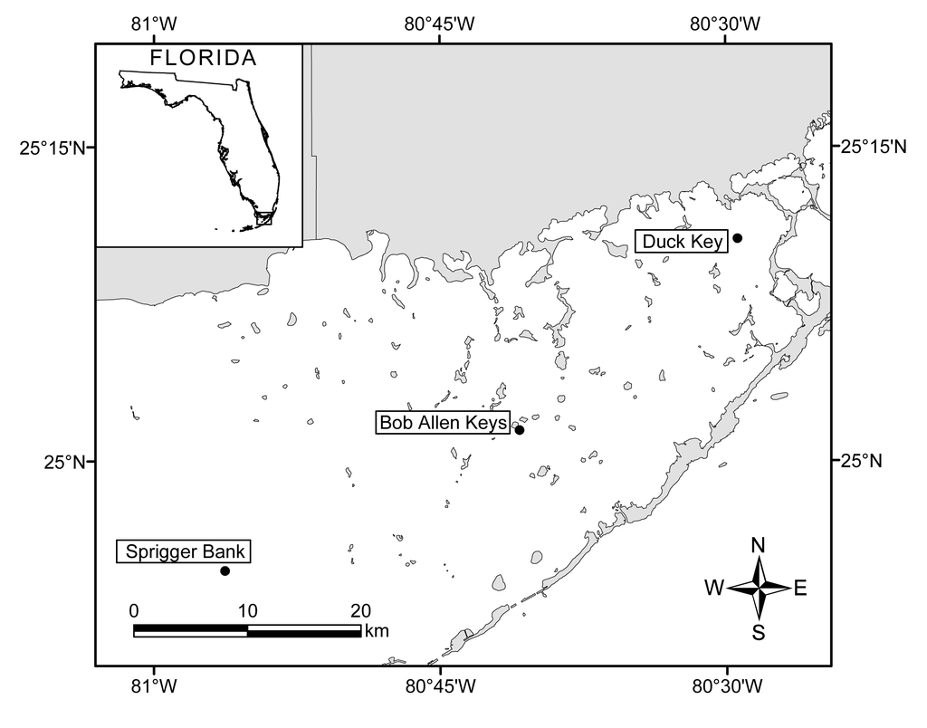

**Figure 1 showing the three surveyed sites within Florida Bay, USA: Sprigger Bank, Bob Allen Keys, and Duck Key.**

##### *Data Collection*

Surveys were conducted four times a year at the study site from 2007 to 2017. At each survey, divers used three randomly placed 0.25m<sup>2</sup> quadrats along a transect line to collect macroalgae by hand. All samples were brought back to the lab, cleaned and separated on the genus level for each quadrat at each site. The samples were dried for 48 hours in an oven set to 70<sup>o</sup>C. Samples for each quadrat were weighed and this was recorded as the dry weight. The samples were ashed using the Loss on Ignition method (LOI) in an oven at 400<sup>o</sup>C for 5 hours (Fourqurean et al. 2012). These ashes were weighed and were recorded as calcium carbonate (CaCO<sub>3</sub>). CaCO<sub>3</sub> was used as a proxy for inorganic carbon. The weight of the CaCO<sub>3</sub> recorded was subtracted from the dry weight previously obtained and this new weight was used as the amount of biomass for each quadrat. Biomass was used as a proxy for organic carbon.

##### *Statistical Analysis*

The data for 2007 to 2017 was separated for each site and an average for each of the three quadrats was obtained so that there were four points representing seasonality for each year. The data cleaned in order to remove any anomalies and then plotted to observe seasonal and annual patterns in biomass trends for each site. The cleaned data was decomposed using a multiplicative time series analysis to confirm seasonal trends and to reveal any underlying overall trends in biomass. The Augmented Dickey Fuller test (ADF) in conjunction with plots of autocorrelation functions (ACF) and partial autocorrelation functions (PACF) were used as tools to determine if differentiation of the data was necessary based on stationarity and autocorrelation. If the data at each site was not stationary, the data was transform using differentiation either once or twice depending the variance within the data and re-tested using these analytical tests. Once the data was stationary, an autoregressive integrated moving average model (ARIMA) was fitted to determine the temporal trends. The goodness of fit of the model and its test for independence was examined by carrying out the Ljung- Box test on its residuals. Data on temperature and salinity were used as explanatory variables both separately and in conjunction to attempt to improve the ARIMA models. The Akaike information criterion (AIC) was then carried out to compare the models. The best fit models were then used to forecast potential trends in biomass at each site for the next 10 years. Statistical analyses were performed using the program RStudio (RStudio, Inc.) and associated packages.

# Results

Across the 11-year survey period, the mean biomass at Sprigger Bank (Figure 2a), the site southwest of the bay, was higher (38.529g/m<sup>2</sup>) and more variable than the mean biomass observed at both Bob Allen Keys (0.4330g/m<sup>2</sup>) (Figure 2b) and Duck Key (2.4559g/m<sup>2</sup>) (Figure 2c), the sites to the northeast of the bay. Decomposition of trends for biomass showed seasonal fluctuation with 10 distinct peaks at each site. Both Sprigger Bank and Duck Key showed overall decreasing trends in biomass across the 11-year survey period. With the lowest values of biomass compared to the other sites (Figure 2b), Bob Allen Keys had an overall fluctuating trend in biomass during the survey period.

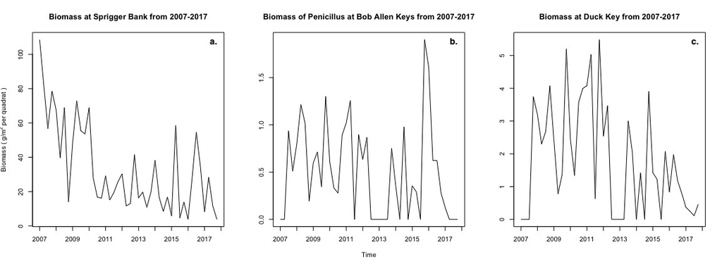

**Figure 2 showing time series of quarterly contributions of biomass by calcareous green macroalgae at each of the three surveryed sites in Florida Bay, USA from February 2007 to December 2017. (a) Seasonal fluctuations of *Halimeda* and *Penicillus* at Sprigger Bank over time, (b) Seasonal fluctuations of biomass of *Penicillus* at Bob Allen Keys over time and (c) Seasonal fluctuations of biomass of *Penicillus* at Duck Key over time.**

For each site, we failed to reject the null hypothesis of non-stationarity using the ADF test p-values of 0.2208 at Sprigger Bank, 0.08574 at Bob Allen Keys and 0.1816 at Duck Key. In order to stabilize the variances and transform the data to remove seasonal trends, second order differencing was carried out on the data for Sprigger Bank and Duck Key while first order differencing was carried out on Bob Allen Keys. Re-runs of the ADF test showed significant p-value of <.01 for the transformed values at each site. ACF and PACF plots confirmed stationarity of the differenced data with uncorrelated values. At Sprigger Bank, the model ‘ARIMA(0,0,0)(1,0,1)[4]’ was the best fit of the data with an AIC value of 345.7815. At Bob Allen Keys, the model ‘ARIMA(1,0,0)(0,0,1)[4]’ was the best fit of the data with an AIC value of 170.8989. At Duck Key, the model ‘ARIMA(0,0,0)(2,0,0)[4]’ was the best fit of the data with an AIC value of 157.5712. All three models were able to generally follow the overall temporal patterns of biomass with similar mean and peaks of the data, however, some extreme peaks were not able to be predicted (Figure 3 a,b,c). ACF and PACF plots of each model along with the Ljung-Box test carried out on the residuals of the model confirmed independence of the data with no significant autocorrelation and normally distributed residuals.

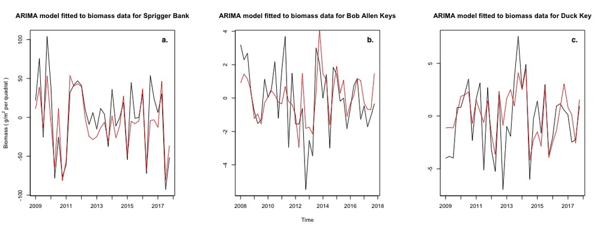

**Figure 3 showing the best fit ARIMA model versus the observed data for each site over the period of 11 years from 2007 to 2017. (a) Modeling of Sprigger Bank using ARIMA(0,0,0)(1,0,1)[4] model, (b) Modeling of Bob Allen Keys ARIMA(1,0,0)(0,0,1)[4] model and (c) Modeling of Duck Key ARIMA(0,0,0)(2,0,0)[4] model.**

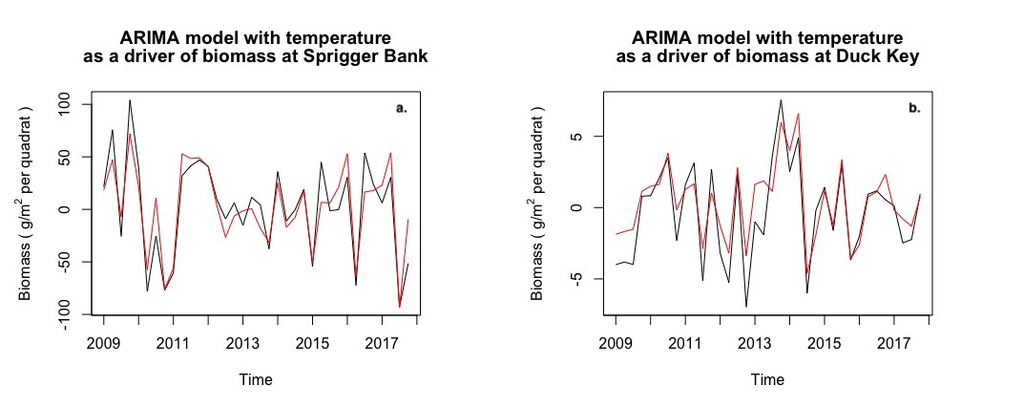

**Figure 4 showing the best fit ARIMA model obtained with temperature as an explanatory variable versus the observed data for each site over the period of 11 years from 2007 to 2017. (a) Modeling of Sprigger Bank using improved model ARIMA(0,0,0)(1,0,2)[4], (b) Modeling of Duck Key using improved model ARIMA(0,0,0)(2,0,1)[4].**

The best fit ARIMA models for each of the sites were used to forecast potential trends of biomass over the next 10-year period from 2018 to 2027 (Figure 5 a,b,c). Trends at Sprigger Bank showed an initial spike in biomass followed by lower biomass values in the following 2021 to 2027 compared to previous years (Figure 5a). The model obtained for Bob Allen Keys forecasted that biomass may go to zero within the near future, starting as early as 2020 based on pervious trends (Figure 5b). At Duck Key, forecasting using the improved model stable trends with overall lower values of biomass at its highest peaks (Figure 5c).

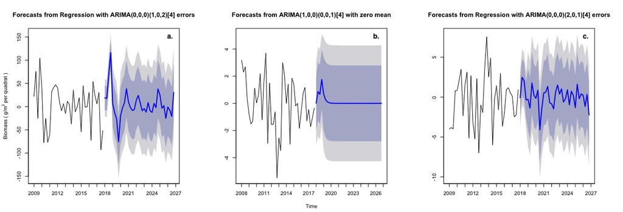

**Figure 5 showing the observed data for each of the sites with forecasted values for biomass for the upcoming 10 year period (2018 to 2027) using best fit ARIMA models. (a) Predicted trends in biomass for Sprigger Bank using ARIMA(0,0,0)(1,0,2)[4], (b) Predicted trends in biomass for Bob Allen Keys using ARIMA(1,0,0)(0,0,1)[4] and (c) Predicted trends in biomass for Duck Key using ARIMA(0,0,0)(2,0,1)[4].**

# Discussion

Long-term studies analyzing spatial and temporal patterns of CGAs are crucial to understanding both fast and slow drivers of algal community distribution. CGAs contribute to approximately 8% of the global carbonate budget and stable abundances play an important role as carbon donors by contributing organic carbon that is transported to other habitats which sequester this carbon long-term (Hill et al. 2015). Biomass across sites in Florida Bay followed a gradient with higher biomass values at Sprigger Bank and significantly lower values of biomass at Duck Key and Bob Allen Keys (Figure 2). This makes sense as Sprigger Bank is in the southwest region of the bay and is the only study site with both genera of *Halimeda* and *Penicillus* present. Morphological characteristics of *Halimeda* have been shown to contriubute to significantly higher growth rates and higher contributions to organic carbon than *Penicillus* (Wefer 1980; Tussenbroek and Dijk 2007).

Over the 11-year study period, seasonal and overal decreasing trends were also observed which mirror seasonal growth patterns observed in other regions, with the highest growth rates during summer due to higher sea surface temperatures (Ortegón-Aznar, Chuc-Contreras, and Collado-Vides 2017). The overall decreasing temporal trends in biomass present at Sprigger Bank and Duck Key can be atrributed to changing abiotic variables associated with climate change such as higher temperature and salinity which typically affect biological processes in CGAs. Based on our data of CGA biomass, ARIMA modeling was able follow the general patterns of mean and variance within the data (Figure 3), however, considering these changing abiotic factos that can potentially affect biological processes can improve the models predictive abilities.

Examining temperature and salinity as both independent and synergistic drivers of algal biomass within ARIMA models for each site at Florida Bay showed that only temperature was a potential explanatory variable (Figure 4). This can be linked to temperature’s strong positive relationship with biological activity which drives the fluctuating seasonal trends observed (Davison, Greene, and Podolak 1991). Similar research conducted on spatiotemporal patterns in seagrass have suggested that the distribution of algal biomass across Florida Bay is due to the environmental heterogeneity of Florida Bay which is characterized by patterns of high nitrogen availability and salinity variability towards the northeast of the bay, and a higher phosphorous and stable salinity towards the southwest of the bay (Frankovich and Fourqurean 1997). While salinity may have important implications spatially, this study showed that temporal patterns of fluctuating salinity are not following overall trends in biomass of CGA within Florida Bay.

Forecasting CGA biomass trends in Florida Bay using the best fit ARIMA models showed potential trends for the next 10-year period from 2008 to 2027. Forecasting trends at both Sprigger Bank and Duck Key showed that decreased overall averages of biomass can occur in as close as 2020 (Figure 5). Forecasting at Bob Allen Keys showed that biomass trends would go to zero as early as 2019 (Figure 5). Based on the incoming quarterly values for biomass we have collected but were unable to analyze within this project, Bob Allen Keys has recorded no CGA biomass during 2018 and 2019 surveys. It is important to continue forecasting trends of CGA in Florida Bay in order to fuel mitigation strategies. CGAs are critical primary producers and the base of community interactions that supports commercially important species for Florida (Zieman, Fourqurean, and Iverson 1989).

Based on increased anthropogenic activity at global, regional and local scales, further studies should be conducted on individual and synergistic effects considering pH and nutrient concentration as additional explanatory variables to improve models. Ocean acidification and eutrophication are other anthropogenic driven issues affecting macroalgal abundance. With projected decreases in seawater pH and shifts in carbonate chemistry, it is important to understand how these may be driving abundance of CGA biomass in Florida Bay due to its negative correlation to CGA biological processes such photosynthesis and calcification (Cornwall et al. 2012; Sinutok et al. 2012). Similarly, a nutrient gradient within Florida Bay has been described as a driving force for seagrass biomass and productivity with phosphorus limited areas having less segrass diversity and abundance (Zieman, Fourqurean, and Iverson 1989; Fourqurean, Zieman, and Powell 1992). No such studies have focused on nutrient limitations on CGA abundance in Florida Bay. Collections of both pH and nutrient concentration data was limited and not steadily measured at any sites within Florida Bay during our study period. Supporting long-term studies and continuing to improve the predictive abilities of these models shown within this study are important in contributing to management decisions for local projects such as CERP and regional projects to sustain biodiversity such as implementing marine protected areas.

# References

Bach, Steven D. 1979. “Standing crop, growth and production of calcareous siphonales (Chlorophyta) in a South Florida lagoon.” 2. Vol. 29. https://www.ingentaconnect.com/content/umrsmas/bullmar/1979/00000029/00000002/art00005?crawler=true{\&}mimetype=application/pdf{\&}casa{\_}token=t5CU9TbnLX8AAAAA:BaQbRyYY{\_}x7hfpwx3NTQnsQ6Jime{\_}5ShVKa2PLe7X3NAdf9tzmV3zYaliAN-SVXVILWUY{\_}q7GvRSb1f13w.

Collado-Vides, Ligia, Leanne M Rutten, and James W Fourqurean. 2005. “Spatiotemporal variation of the abundance of calcareous green macroalgae in the Florida Keys: A study of synchrony within a macroalgal functional-form group.” *Journal of Phycology* 41: 742–52. https://doi.org/10.1111/j.1529-8817.2005.00099.x.

Cornwall, Christopher E., Christopher D. Hepburn, Daniel Pritchard, Kim I. Currie, Christina M. McGraw, Keith A. Hunter, and Catriona L. Hurd. 2012. “Carbon-use strategies in macroalgae: differential responses to lowered pH and implications for ocean acidification.” *Journal of Phycology* 48 (1). John Wiley & Sons, Ltd (10.1111): 137–44. https://doi.org/10.1111/j.1529-8817.2011.01085.x.

Davison, I R, R M Greene, and E J Podolak. 1991. “Temperature acclimation of respiration and photosynthesis in the brown alga Laminaria saccharina *.” Vol. 110. https://link.springer.com/content/pdf/10.1007/BF01344363.pdf.

Fourqurean, James W., Carlos M. Duarte, Hilary Kennedy, Núria Marbà, Marianne Holmer, Miguel Angel Mateo, Eugenia T. Apostolaki, et al. 2012. “Seagrass ecosystems as a globally significant carbon stock.” *Nature Geoscience* 5 (7). Nature Publishing Group: 505–9. https://doi.org/10.1038/ngeo1477.

Fourqurean, James W., Joseph C. Zieman, and George V. N. Powell. 1992. “Phosphorus limitation of primary production in Florida Bay: Evidence from C:N:P ratios of the dominant seagrass Thalassia testudinum.” *Limnology and Oceanography* 37 (1). John Wiley & Sons, Ltd: 162–71. https://doi.org/10.4319/lo.1992.37.1.0162.

Franklin, Jerry F. 1989. “Importance and Justification of Long-Term Studies in Ecology.” In *Long-Term Studies in Ecology*, 3–19. New York, NY: Springer New York. https://doi.org/10.1007/978-1-4615-7358-6_1.

Frankovich, Thomas A, and James W Fourqurean. 1997. “Seagrass epiphyte loads along a nutrient availability gradient, Florida Bay, USA.” Vol. 159. https://www.int-res.com/articles/meps/159/m159p037.pdf.

Herbert, Darrell A., and James W. Fourqurean. 2009. “Phosphorus Availability and Salinity Control Productivity and Demography of the Seagrass Thalassia testudinum in Florida Bay.” *Estuaries and Coasts* 32 (1). Springer: 188–201. https://doi.org/10.1007/s12237-008-9116-x.

Hill, Ross, Alecia Bellgrove, Peter I. Macreadie, Katherina Petrou, John Beardall, Andy Steven, and Peter J. Ralph. 2015. “Can macroalgae contribute to blue carbon? An Australian perspective.” *Limnology and Oceanography* 60 (5). John Wiley & Sons, Ltd: 1689–1706. https://doi.org/10.1002/lno.10128.

Hillis-Colinvaux, Llewellya. 1980. “Ecology and Taxonomy of Halimeda: Primary Producer of Coral Reefs.” *Advances in Marine Biology* 17 (January). Academic Press: 1–327. https://doi.org/10.1016/S0065-2881(08)60303-X.

Ortegón-Aznar, Ileana, Andrea Chuc-Contreras, and Ligia Collado-Vides. 2017. “Calcareous green algae standing stock in a tropical sedimentary coast.” *Journal of Applied Phycology* 29 (5). Springer Netherlands: 2685–93. https://doi.org/10.1007/s10811-017-1057-y.

Perry, William. 2004. “Elements of South Florida’s Comprehensive Everglades Restoration Plan.” *Ecotoxicology*, no. 13: 185–93. www.saj.usace.army.mil/projects/index.html.

Sinutok, S., R. Hill, M. A. Doblin, M. Kühl, and P. J. Ralph. 2012. “Microenvironmental changes support evidence of photosynthesis and calcification inhibition in Halimeda under ocean acidification and warming.” *Coral Reefs* 31 (4). Springer-Verlag: 1201–13. https://doi.org/10.1007/s00338-012-0952-6.

Tussenbroek, Brigitta I. van, and M. Guadalupe Barba Santos. 2011. “Demography of Halimeda incrassata (Bryopsidales, Chlorophyta) in a Caribbean reef lagoon.” *Marine Biology* 158 (7). Springer: 1461–71. https://doi.org/10.1007/s00227-011-1662-2.

Tussenbroek, Brigitta I. van, and Jent Kornelis van Dijk. 2007. “Spatial and temporal variability in biomass and production of psammophytic Halimeda incrassata (Bryopsidales, Chlorophyta) in a Caribbean reef lagoon.” *Journal of Phycology* 43 (1). John Wiley & Sons, Ltd: 69–77. https://doi.org/10.1111/j.1529-8817.2006.00307.x.

Wefer, Gerold. 1980. “Carbonate production by algae Halimeda, Penicillus and Padina.” Vol. 285. https://www.nature.com/articles/285323a0.pdf?origin=ppub.

Zieman, Joseph C, James W Fourqurean, and Richard L Iverson. 1989. “Distribution, abundance and productivity of seagrasses and macroalgae in Florida Bay.” 1. Vol. 44. https://www.ingentaconnect.com/content/umrsmas/bullmar/1989/00000044/00000001/art00024?crawler=true{\&}casa{\_}token=opOrRAUO-uMAAAAA:uwe8u30Jk47-Xx2jqbvlwsNPp48AGfzmUl1DPqc9e5xyc4LQc2D7Tl2Bg0FeI70-brvnuU3KofL2yiGP{\_}g.